# Cod and sprat in a power-law background

Do the two Allee mechanisms survive when the rest of the community is a background of other prey and other predators?

Published

November 11, 2026

```r
library(mizer)
library(ggplot2)
options(mizer_info_level = 0)
source("R/build_model.R")
source("R/combined_model.R")
source("R/background_model.R")

# Results of the scripts in background/
res <- readRDS("background/scan.rds")
scan <- res$scan
cases <- readRDS("background/cases.rds")
fishing <- readRDS("background/fishing.rds")

col_species <- c(Sprat = "#2a78d6", Cod = "#eb6834")
theme_set(theme_minimal(base_size = 12) +
              theme(panel.grid.minor = element_blank(),
                    legend.position = "top",
                    strip.text = element_text(face = "bold", hjust = 0)))
fmt <- function(x, digits = 2) format(signif(x, digits), big.mark = ",",
                                      scientific = FALSE, trim = TRUE)
#' A biomass relative to the coexistence state, as text
biomass_text <- function(x, alive = 1e-3) {
    ifelse(x < alive, "dies out",
           ifelse(x > 1e3, "> 1000×", sprintf("%.2f×", x)))
}
#' "min–max" of x with a fixed number of decimals
range_text <- function(x, decimals = 2) {
    paste(sprintf(paste0("%.", decimals, "f"), range(x)), collapse = "–")
}
#' The scan result at one grid point
at <- function(phi_prey, phi_larv, cod_resource) {
    scan[abs(scan$phi_prey - phi_prey) < 1e-9 &
             abs(scan$phi_larv - phi_larv) < 1e-9 &
             scan$cod_resource == cod_resource, ]
}
variant_label <- function(cod_resource) {
    factor(ifelse(cod_resource, "Cod larvae eat plankton",
                  "Cod larvae eat background food only"),
           levels = c("Cod larvae eat background food only",
                      "Cod larvae eat plankton"))
}
scan$variant <- variant_label(scan$cod_resource)
```

```r
# What happens at each point of the scan
#   barrier    a rare cod cannot invade the cod-free state
#   unstable   the coexistence state has an eigenvalue with a positive real
#              part (well above rounding error)
#   cycles     cod started 20 % above the coexistence state still vary by
#              more than 5 % over the last 100 of 1000 years
#   dying      cod started 20 % above it are below 1 % of it after 1000
#              years. At one point they are then still at 0.5 % and falling;
#              a longer run in background/run_cases.R shows them dying out.
scan$barrier <- scan$R0 < 0.999
scan$unstable <- scan$lead_re > 1e-6
scan$cycles <- scan$above_cod_max > 1.05 * scan$above_cod_min
scan$dying <- scan$above_cod < 0.01
alive <- 1e-3
regimes <- c("No barrier: cod invade",
             "Barrier. Coexistence state stable",
             "Barrier. Threshold: cod settle above it",
             "Barrier. Threshold: cod cycle above it",
             "Barrier. Cod die out from above and below")
scan$regime <- factor(regimes[with(scan, ifelse(
    !barrier, 1, ifelse(
        !unstable, 2, ifelse(
            dying, 5, ifelse(cycles, 4, 3)))))],
    levels = regimes)
n_regime <- function(k, cod_resource = c(TRUE, FALSE)) {
    sum(scan$regime %in% regimes[k] & scan$cod_resource %in% cod_resource)
}
# The points at which cod hold sprat down
on <- scan[scan$phi_prey > 0, ]
# The cod states above the threshold, where cod have clearly left it
strong_above <- scan[scan$regime == regimes[3] & scan$above_cod > 1.05, ]
```

```r
# The coexistence state with both links close to their largest strength
p_max <- new_background_params(phi_prey = 0.96, phi_larv = 0.96)
shares <- background_shares(p_max)
theta_max <- other_params(p_max)$background$theta_max
sp_max <- as.data.frame(species_params(p_max))
dlnw <- log(w(p_max)[2] / w(p_max)[1])
#' Size at which a share is largest
w_peak <- function(x) w(p_max)[which.max(x)]
#' Share at the size class nearest to w
share_at <- function(x, w0) x[which.min(abs(w(p_max) - w0))]
# Who eats the background prey, and what stays fixed
prey_mort <- background_prey_mort(p_max)
sprat_prey_share <- prey_mort["Sprat", ] / colSums(prey_mort)
#' Value of x at the size of the resource spectrum nearest to w0
at_prey <- function(x, w0) x[which.min(abs(w_full(p_max) - w0))]
fixed_share <- ext_encounter(p_max) / getEncounter(p_max)
# With cod larvae eating background food only
p_larval <- new_background_params(phi_prey = 0.96, phi_larv = 0.96,
                                  cod_resource = FALSE)
fixed_larval <- (ext_encounter(p_larval) / getEncounter(p_larval))["Cod", ]
level <- other_params(p_max)$background$background_level
# The same state with the links at half strength: every rate is the same
p_half <- new_background_params(phi_prey = 0.48, phi_larv = 0.48)
# (at the sizes at which the species occur)
present <- initialN(p_max) > 0
same_rates <- max(abs(getEGrowth(p_half) / getEGrowth(p_max) - 1)[present],
                  abs(getMort(p_half) / getMort(p_max) - 1)[present],
                  na.rm = TRUE)

sens <- cases$sensitivity
intro <- cases$intro
pts <- cases$points
# The two slow points of the scan. Cycle: troughs of cod after the transient
slow <- cases$slow
slow_cycle <- slow[slow$phi_prey == 0.36 & slow$factor == 1.2 &
                       slow$time > 300, ]
slow_troughs <- slow_cycle$time[which(diff(sign(diff(slow_cycle$cod))) == 2) + 1]
slow_period <- diff(slow_troughs)[1]
# Scan results at the four points
pt <- lapply(seq_len(nrow(pts)), function(i) {
    at(pts$phi_prey[i], pts$phi_larv[i], pts$cod_resource[i])
})

# Fishing
fb <- fishing$branches
fb$sweep <- factor(fb$sweep, levels = fishing$sweeps)
fb$case <- factor(fb$case, levels = fishing$cases$label)
abundant <- 0.1
up <- fb[fb$sweep == fishing$sweeps[1], ]
up1 <- up[up$case == fishing$cases$label[1], ]
up2 <- up[up$case == fishing$cases$label[2], ]
# Without a barrier the runs settle very slowly near the fishing mortality
# at which cod vanish. Only the settled steps are used.
up3 <- up[up$case == fishing$cases$label[3] & up$converged, ]
down <- fb[fb$sweep == fishing$sweeps[2], ]
down3 <- down[down$case == fishing$cases$label[3] & down$converged, ]
#' Last fishing mortality with cod above `floor`, and the first without
last_F <- function(d, floor = abundant) max(d$F_cod[d$Cod > floor])
collapse_F <- function(d, floor = abundant) {
    min(d$F_cod[d$F_cod > last_F(d, floor)])
}
#' Cod biomass on a branch at one fishing mortality
cod_at <- function(d, F_cod) d$Cod[abs(d$F_cod - F_cod) < 1e-9]
# Without a barrier: how far the two sweeps are apart
sweep_gap <- max(abs(down3$Cod[match(up3$F_cod, down3$F_cod)] - up3$Cod),
                 na.rm = TRUE)
unsettled <- up$F_cod[up$case == fishing$cases$label[3] & !up$converged]
sf <- fishing$sprat_fishery
sf1 <- sf[sf$case == fishing$cases$label[1], ]
sf2 <- sf[sf$case == fishing$cases$label[2], ]
sf3 <- sf[sf$case == fishing$cases$label[3], ]
# Natural mortality of cod at the third point
p_open <- new_background_params(pts$phi_prey[3], pts$phi_larv[3],
                                pts$cod_resource[3])
cod_mort <- function(w0) getMort(p_open)["Cod", which.min(abs(w(p_open) - w0))]
```

# 1 Summary

The combined model showed two mechanisms that can keep a collapsed cod stock from recovering: the emergent Allee effect of Van Leeuwen et al. (2008), in which a rare cod finds too little sprat to eat, and cultivation–depensation (Walters and Kitchell 2001), in which abundant sprat eat cod eggs and larvae. In that model cod, sprat and plankton are the whole community.

Here the two species are embedded in a **power-law background**. In the coexistence state every fish meets food and dies at power-law rates, as in a community with a Sheldon spectrum. Only part of those rates comes from the other species and from the plankton. The rest is the background:

- a **background mortality**, which is fixed;
- **background prey**, which cod and sprat eat down and which recovers when they eat less, as the plankton does.

Two parameters, `phi_prey` and `phi_larv`, set how much of the power-law rates the two predation links account for, from none (0) to as much as they can (1).

The main results:

- **Cultivation–depensation persists.** Sprat predation on cod larvae lowers the invasion fitness $R_0$ of cod in the cod-free state by a factor of up to 26.
- **The mechanism of Van Leeuwen et al. does not.** Sprat as food *raise* $R_0$ in the cod-free state, by a factor of up to 2.1. In a power-law background, cod depend on sprat only at 30 g to 1 kg, when they eat adult sprat, and there are more adult sprat without cod.
- **Competition takes its place.** If cod larvae eat plankton, the more numerous sprat leave them less. That lowers $R_0$ by a factor of up to 3.1. Sprat also graze down the small background prey that juvenile cod eat.
- **The background prey works against every barrier.** A rare cod has to itself the background prey that the cod of the coexistence state eat down. That raises $R_0$ by a factor of 1.2–3.1. The cod-free state is closed only where the links are strong: at 64 of the 162 points of the scan. With both links at half strength, $R_0$ is 1.4 without and 0.87 with competition for plankton.
- **Cod limit themselves.** More cod leave less background prey. Where cod can invade, the coexistence state is stable and is the only cod state. In no run do cod take over or grow without bound.
- **Behind a barrier the coexistence state is mostly the Allee threshold.** It is stable at only 8 of the 64 points with a barrier. At the others cod started below it die out. Cod started above it settle at a state with more cod and fewer sprat, cycle, or at the strongest links die out too.
- **The cod states withstand very little cod fishing.** Behind a barrier they collapse at a fishing mortality of 0.003/yr and 0.004/yr, and cod do not return when fishing stops. Without a barrier cod decline steadily and are gone at 0.04/yr. The combined model’s cod state persisted up to 0.27/yr.
- **A sprat fishery opens the way back.** It lets cod invade the cod-free state from a sprat fishing mortality of 0.1–0.25/yr at the two points with a barrier that were tried.
- **How far the background prey gives way is a free choice, and it matters.** At one point of the scan, $R_0$ is 0.99 if the prey sits at 0.2 of its carrying capacity, 0.6 at the default of 0.5, and 0.44 if the background is fixed.

# 2 The model

## 2.1 A background

In the cod–sprat model and in the combined model, cod, sprat and plankton are the whole community. All sprat mortality above 0.01 g is cod predation or a constant, and cod above the diet-shift size eat sprat or starve. Real cod and sprat have many other predators and prey. Those soften every feedback between the two species.

Here the two species live in a community that is not modelled. In the coexistence state every individual

- meets food at a rate proportional to $w^n$, with $n = 0.7$, and
- dies at a rate proportional to $w^{n-1}$,

as it would in a community with a Sheldon spectrum. Only part of that food and of that mortality comes from the modelled species and from the plankton. The rest is the **background**:

- **Background mortality** is fixed. It does not change when cod or sprat do.
- **Background prey** stands for the other animals that cod and sprat eat. It is depleted by what they eat of it and recovers when they eat less, as the plankton does.

## 2.2 Construction

`new_background_params()` in `R/background_model.R` builds the model with the allometric workflow of the mizerEcopath package:

1. **`newAllometricParams()`** sets up cod and sprat without any interaction. Each species has a power-law encounter rate, chosen to give its age at maturity, and a power-law mortality, chosen so that the juvenile biomass density falls as $w^{-0.2}$. There is no satiation and no metabolic loss. The species are in steady state, with the biomasses of the cod state of the cod–sprat model.
2. **`setFeedingLevels()`** introduces satiation and metabolism: a feeding level of 0.6 and a critical feeding level of 0.2 at all sizes. It raises the encounter rate so that growth is unchanged. From here on the species respond to a change in food.
3. **`makeInteracting()`** switches on two predation links: cod eat sprat, and sprat eat cod eggs and larvae. Whatever predation this creates is subtracted from the external encounter and the external mortality.
4. **`setResourceInteraction()`** lets the species feed on a dynamic plankton resource, a power law up to 0.1 g. Feeding on plankton replaces as much of the external encounter as it can. The plankton is a semichemostat at half its carrying capacity.
5. **`set_background_response()`**, in `R/background_model.R`, turns the external encounter that is left into feeding on background prey (Section 2.4).

Steps 2–5 move food and mortality from the background to the modelled world but do not change any rate. So the coexistence state is the **same steady state for every strength of the links**: with the links at half strength, growth and mortality differ from those at nearly full strength only by rounding error (a relative difference below $10^{-13}$). The combined model had to recalibrate `erepro` at every point to hold its cod state fixed. Here that comes for free.

Life histories are those of the earlier models (sprat to 15 g, cod to 10 kg, predator–prey mass ratios of 1000 and 30). Both species enter as 1 mg eggs, and there is no imposed stock–recruitment relation (`R_max = Inf`).

## 2.3 The two links

The strength of each link is a fraction φ of the largest strength for which the background stays non-negative:

- **`phi_prey`**: cod eating sprat. At 1, the cod that depend most on sprat get all their food from sprat.
- **`phi_larv`**: sprat eating cod eggs and larvae. At 1, the cod that sprat eat most die only from sprat predation.

At 0 a link is absent and its share stays in the background. φ is therefore a measure of how little the background dilutes a link.

## 2.4 The background prey

The background prey is a second spectrum of food next to the plankton:

- **What it is.** The power law of the plankton, continued from the largest plankton size of 0.1 g up to the size of the largest cod.
- **Who eats it.** Both species, through their predation kernels. Each predator finds it with an availability that depends on its own size. The availability is chosen so that the predator’s encounter rate in the coexistence state does not change.
- **How it responds.** Each size class is a semichemostat, like the plankton. In the coexistence state it sits at a **background level** of 0.5: that fraction of its carrying capacity. If the predation on a size class changes by a factor $x$, its abundance settles at $1 / (\lambda + (1 - \lambda) x)$ of what it was, with $\lambda$ the background level.
  - Prey that is no longer eaten rises by a factor of 2.
  - Prey that is eaten twice as much falls to 0.67.
  - At a level of 1 the background food is fixed.
- **What stays fixed.** External food responds only as far as a Sheldon spectrum would supply it from prey above 0.1 g. Small larvae could reach such prey only with the tail of their kernel.
  - With cod larvae eating plankton, at most 0.3 % of the food of cod stays fixed.
  - With cod larvae eating background food only, their food is fixed up to 0.1 g, and 78 % fixed at 1 g and 5 % at 10 g.

The background prey is held in mizer’s resource spectrum, above the plankton. So `getStability()`, the Newton solver and `cod_R0()` treat it as part of the state, as they do the plankton.

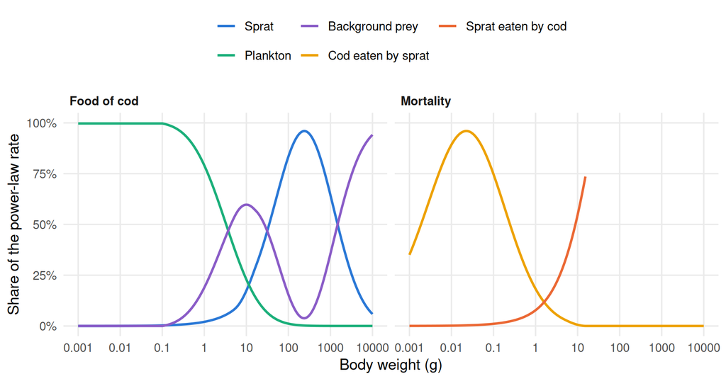

Figure 1: What the modelled world accounts for in the coexistence state, with both links at φ = 0.96 and cod larvae feeding on plankton. Left: shares of the food of cod. Right: shares of the mortality of each species. The remainder of the mortality is the fixed background.

```r
share_data <- rbind(
    data.frame(panel = "Food of cod", w = w(p_max),
               share = shares$prey["Cod", ], what = "Sprat"),
    data.frame(panel = "Food of cod", w = w(p_max),
               share = shares$resource["Cod", ], what = "Plankton"),
    data.frame(panel = "Food of cod", w = w(p_max),
               share = shares$background["Cod", ], what = "Background prey"),
    data.frame(panel = "Mortality", w = w(p_max),
               share = shares$predation["Cod", ],
               what = "Cod eaten by sprat"),
    data.frame(panel = "Mortality", w = w(p_max)[present["Sprat", ]],
               share = shares$predation["Sprat", present["Sprat", ]],
               what = "Sprat eaten by cod"))
share_data$what <- factor(share_data$what, levels = unique(share_data$what))
ggplot(share_data, aes(w, share, colour = what)) +
    geom_line(linewidth = 0.9) +
    facet_wrap(~panel) +
    scale_x_log10(breaks = 10^(-3:4),
                  labels = c("0.001", "0.01", "0.1", "1", "10", "100",
                             "1000", "10000")) +
    scale_y_continuous(limits = c(0, 1), labels = scales::percent) +
    scale_colour_manual(values = c("#2a78d6", "#1baf7a", "#8a5cc7", "#eda100",
                                   "#eb6834"), name = NULL) +
    labs(x = "Body weight (g)", y = "Share of the power-law rate") +
    guides(colour = guide_legend(nrow = 2))
```

Figure 1 shows what the links can account for at most. The pattern follows from the shapes of the spectra. The abundance of one species falls as $w^{-1.2}$ among its juveniles. The community that the power-law rates stand for falls as $w^{-2.05}$. A species therefore matters to others mainly **near its own largest sizes**:

- **Sprat as food.** Cod of about 200 g, which eat adult sprat, can get 96 % of their food from sprat. Cod of 1 g get 2 %, and cod of 0.1 g 0.3 %. The small sprat that small cod eat are a negligible part of the food at that size.
- **Cod as predators.** Cod cause up to 74 % of the mortality of the largest sprat, but only 1 % of that of 0.1 g sprat.
- **Sprat as predators.** Adult sprat can cause 96 % of the mortality of cod larvae of 0.02 g, and 35 % of that of eggs.
- **Plankton.** Sprat get nearly all their food from plankton (85 % or more), which is what regulates them. Cod larvae up to 0.1 g can get 99.7 % of theirs from plankton, and then compete with sprat.
- **Background prey.** It is the rest of the food of cod above 0.1 g: 60 % at 10 g, 5 % at 300 g, where cod eat most sprat, and 73 % at 3 kg. Sprat take at most 15 % of their food from it. But sprat are many, so they cause 97 % of the mortality of background prey of 0.15 g and 76 % of that of 1 g. Above 10 g only cod eat it. Juvenile cod of 0.3 to 30 g therefore share their background prey with sprat.

This already bears on the two mechanisms. Cultivation–depensation needs adult forage fish to eat the young of their predator, which the embedding allows at almost full strength. The mechanism of Van Leeuwen et al. (2008) needs juvenile cod to depend on small sprat, which it does not allow: in a power-law background the dependence of cod on sprat lies with cod of 30 g to 1 kg that eat adult sprat.

## 2.5 Cod larvae and plankton

`setResourceInteraction()` moves food from the background to the plankton for both species. Cod larvae then share their food with sprat. The combined model deliberately kept this competition out by giving cod larvae a fixed food. Both variants are studied here:

- **Cod larvae eat plankton** (`cod_resource = TRUE`): the workflow as it stands.
- **Cod larvae eat background food only** (`cod_resource = FALSE`): the plankton share of the cod diet is handed back to the background, where it is a fixed food (Section 2.4). This is the closer analogue of the combined model.

## 2.6 Numerics

The model uses mizer’s first-order upwind scheme without size diffusion, as the workflow produces it and as in the cod–sprat model, on 200 size classes ($\Delta \ln w = 0.081$). The combined model’s second-order scheme with size diffusion was not carried over: with diffusion, `steadySingleSpecies()` leaves an unbalanced diffusive flux out of the largest size class of each species. The combined model avoided that with a senescence mortality, which would break the power law.

Steady states other than the coexistence state are found by projection, with Euler steps of 0.1 yr. $R_0$ comes from `cod_R0()` of the combined model, which solves the discretised transport equation and is exact for this scheme.

# 3 Telling the mechanisms apart

As in the combined model, the invasion fitness $R_0$ of a rare cod in the cod-free state is decomposed by taking one thing from the cod-free state and the rest from the coexistence state, where $R_0 = 1$:

- **Prey**: the sprat that cod eat. This is the route of Van Leeuwen et al. (2008). It is below 1 if cod find less sprat to eat without cod.
- **Competition**: the plankton that cod eat. It is below 1 if the more numerous sprat leave less plankton for cod larvae. This route is absent when cod larvae eat background food only.
- **Background**: the background prey that cod eat. Two things pull it in opposite directions. The prey that only cod ate recovers without cod, which raises it. The more numerous sprat graze down the small background prey that juvenile cod eat, which lowers it.
- **Food**: all three together, that is the growth and reproduction of cod.
- **Larval predation**: the mortality of cod. This is cultivation–depensation.
- **Interaction** = $R_0$ / (food × larval predation). It is below 1 if hungry cod linger at the sizes at which sprat eat them.

$R_0 < 1$ means that cod cannot invade the cod-free state. In the combined model that implied two alternative stable states, because the cod state was stable. Here the coexistence state need not be stable, so its stability is checked separately: from the leading eigenvalue of `getStability()`, and by starting cod 20 % below and 20 % above it.

# 4 Results

## 4.1 The cod-free state

Removing cod takes away part of the mortality of sprat, mostly that of the adults (Figure 1), and all the mortality of the background prey that only cod eat. Sprat biomass then rises by a factor of 1.07–1.81, depending on `phi_prey` only. The plankton that sprat graze falls, and with it the feeding level of sprat.

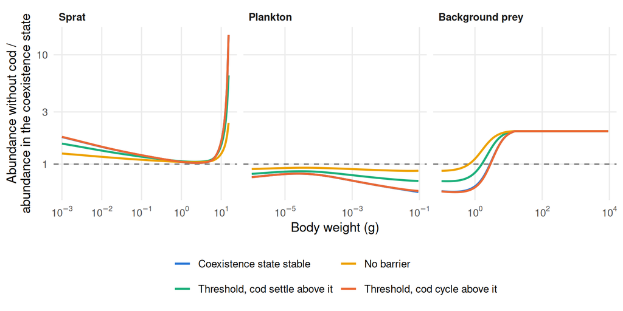

Figure 2: The cod-free state relative to the coexistence state at the four points of Table 2: abundance of sprat, of plankton and of background prey by size. Without cod there are more sprat. They graze down the plankton and the small background prey, and the large background prey recovers. The first and last points have the same prey link, so their curves nearly coincide.

```r
spec <- cases$spectra[cases$spectra$what != "Sprat feeding level", ]
spec$point <- factor(spec$point, levels = pts$label)
spec$what <- factor(spec$what, levels = c("Sprat", "Plankton",
                                          "Background prey"))
# The largest background prey is eaten by no one and does not change
w_eaten <- max(w_full(p_max)[colSums(prey_mort) > 0])
spec <- spec[spec$what != "Background prey" | spec$w <= w_eaten, ]
ggplot(spec[spec$w >= 1e-6, ], aes(w, ratio, colour = point)) +
    geom_hline(yintercept = 1, colour = "grey45", linetype = "dashed") +
    geom_line(linewidth = 0.9) +
    facet_wrap(~what, scales = "free_x") +
    scale_x_log10(labels = scales::label_log()) +
    scale_y_log10() +
    scale_colour_manual(values = c("#2a78d6", "#1baf7a", "#eda100",
                                   "#eb6834"), name = NULL) +
    labs(x = "Body weight (g)",
         y = "Abundance without cod /\nabundance in the coexistence state") +
    guides(colour = guide_legend(nrow = 2)) +
    theme(legend.position = "bottom")
```

```r
spectra <- cases$spectra
#' A column of the spectra at point i, at the size nearest to w0
spec_at <- function(i, what, w0) {
    d <- spectra[spectra$point == pts$label[i] & spectra$what == what, ]
    d$ratio[which.min(abs(log(d$w / w0)))]
}
```

## 4.2 The regime map

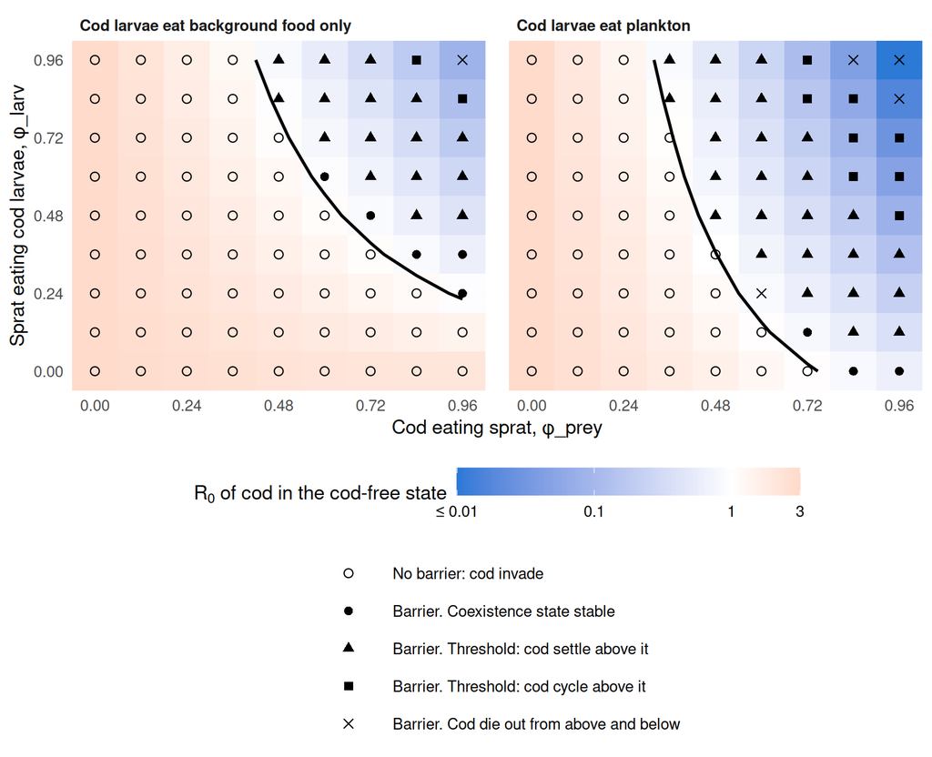

Figure 3: $R_0$ of a rare cod in the cod-free state over the strengths of the two links. The black line is $R_0 = 1$: above and to the right of it cod cannot invade. The symbols show what the coexistence state is (see text).

```r
map <- scan
map$log_R0 <- pmin(pmax(log10(map$R0), -2), 0.5)
ggplot(map, aes(phi_prey, phi_larv)) +
    geom_raster(aes(fill = log_R0)) +
    geom_contour(aes(z = log_R0), breaks = 0, colour = "black",
                 linewidth = 0.9) +
    geom_point(aes(shape = regime), size = 2.2) +
    facet_wrap(~variant) +
    scale_fill_gradient2(low = "#2a78d6", mid = "white", high = "#eb6834",
                         midpoint = 0, limits = c(-2, 0.5),
                         breaks = c(-2, -1, 0, 0.5),
                         labels = c("≤ 0.01", "0.1", "1", "3"),
                         name = expression(R[0] ~ "of cod in the cod-free state")) +
    scale_shape_manual(values = c(1, 16, 17, 15, 4), name = NULL, drop = FALSE) +
    scale_x_continuous(expand = c(0, 0), breaks = seq(0, 0.96, by = 0.24)) +
    scale_y_continuous(expand = c(0, 0), breaks = seq(0, 0.96, by = 0.24)) +
    labs(x = "Cod eating sprat, φ_prey",
         y = "Sprat eating cod larvae, φ_larv") +
    guides(fill = guide_colourbar(order = 1),
           shape = guide_legend(order = 2, ncol = 1)) +
    theme(legend.position = "bottom", legend.box = "vertical",
          legend.key.width = unit(1.5, "cm"), panel.spacing = unit(1, "lines"))
```

Figure 3 shows the invasion fitness of cod in the cod-free state and, as symbols, what the coexistence state is.

**Can cod invade?** Without cod, the background prey that cod had eaten down recovers. Where cod do not eat sprat (`phi_prey` = 0) hardly anything else changes, and $R_0$ is 3.06: a rare cod finds more food than the cod of the coexistence state, and cod return to that state. Every barrier has to overcome this head start. It needs `phi_prey` > 0, because only then are there more sprat without cod.

```r
barrier_from <- function(cod_resource) {
    d <- scan[scan$cod_resource == cod_resource, ]
    sapply(sort(unique(d$phi_prey)), function(pp) {
        k <- d[abs(d$phi_prey - pp) < 1e-9, ]
        if (all(k$barrier)) return("always")
        if (!any(k$barrier)) return("never")
        sprintf("%.2f", approx(k$R0, k$phi_larv, xout = 1)$y)
    })
}
barrier_table <- rbind(barrier_from(FALSE), barrier_from(TRUE))
colnames(barrier_table) <- sprintf("%.2f", sort(unique(scan$phi_prey)))
knitr::kable(data.frame(
    `φ_prey` = c("Cod larvae eat background food only",
                 "Cod larvae eat plankton"),
    barrier_table, check.names = FALSE), align = "lrrrrrrrrr")
```

Table 1: The strength `phi_larv` of sprat predation on cod larvae from which cod cannot invade the cod-free state, by the strength `phi_prey` of cod predation on sprat. It is interpolated between the points of the scan.

| φ_prey | 0.00 | 0.12 | 0.24 | 0.36 | 0.48 | 0.60 | 0.72 | 0.84 | 0.96 |
| --- | --- | --- | --- | --- | --- | --- | --- | --- | --- |
| Cod larvae eat background food only | never | never | never | never | 0.79 | 0.55 | 0.40 | 0.30 | 0.23 |
| Cod larvae eat plankton | never | never | never | 0.76 | 0.37 | 0.15 | 0.02 | always | always |

- **Cod larvae eat background food only** (left). Larval predation is the only barrier. It closes the cod-free state at 24 of the 81 points, where both links are strong (Table 1). At the strongest links $R_0$ is 0.082.
- **Cod larvae eat plankton** (right). Competition adds to larval predation, and the cod-free state is closed at 40 points. From a `phi_prey` of 0.84 it is closed even without larval predation ($R_0$ = 0.84 and 0.63). At the strongest links $R_0$ is 0.01.

**Two points are slow.** Both were followed for 3000 years (`background/run_cases.R`):

- **A slow cycle where cod can invade.** At `phi_prey` = 0.36 and `phi_larv` = 0.72, with cod larvae eating plankton, $R_0$ is 1.03 and the coexistence state is unstable, with a growth rate of 0.005/yr. Cod cycle between 0.54 and 1.4 times their coexistence biomass, with a period of about 2,300 years.
- **A slow death.** At `phi_prey` = 0.6 and `phi_larv` = 0.24, with cod larvae eating plankton, the leading eigenvalues are a complex pair with a real part of 0.001/yr. Cod started 20 % above the state return to it, pass it and die out. They are still at 0.5 % of it after 1000 years.

**Cod limit themselves.** In no run do cod take over, and in none do they grow without bound: the largest cod biomass that any run from above reaches is 1.7 times that of the coexistence state, and sprat never fall below 0.14 of theirs. The background prey gives way under more cod.

**Why is the coexistence state unstable where there is a barrier?** With `R_max = Inf`, cod are regulated only through what they do to their food and to sprat. More cod mean less background prey and fewer sprat, and that has four effects on cod:

- less background prey to eat, which stabilises;
- less sprat to eat, which stabilises;
- fewer larvae eaten, which destabilises;
- more plankton for cod larvae, which destabilises.

The last two are the mechanisms that close the cod-free state. Where they are strong enough to do that against the head start that the background prey gives a rare cod, they are mostly also strong enough to outweigh the first two at the coexistence state. So the line $R_0 = 1$ and the edge of stability lie close together in Figure 3, with the bistable band between them.

```r
#' Biomass after the run from above: a range where it still varies
above_text <- function(lo, hi) {
    ifelse(hi > 1.05 * lo & hi > alive,
           sprintf("%.2f–%.2f×", lo, hi), biomass_text(hi))
}
# Sprat over the last 100 years of the runs from above in background/cases.rds
sprat_above <- lapply(pts$label, function(l) {
    d <- cases$departures
    d$sprat[d$point == l & d$factor > 1 & d$time > max(d$time) - 100]
})
knitr::kable(data.frame(
    Point = pts$label,
    φ_prey = pts$phi_prey,
    φ_larv = pts$phi_larv,
    `Cod larvae eat plankton` = ifelse(pts$cod_resource, "yes", "no"),
    Prey = sprintf("%.2f", sapply(pt, `[[`, "prey")),
    Competition = sprintf("%.2f", sapply(pt, `[[`, "competition")),
    Background = sprintf("%.2f", sapply(pt, `[[`, "background")),
    `Larval predation` = sprintf("%.2f", sapply(pt, `[[`, "larval_predation")),
    R0 = sprintf("**%.2f**", sapply(pt, `[[`, "R0")),
    `Growth rate of the instability (1/yr)` = ifelse(
        sapply(pt, `[[`, "unstable"),
        sprintf("%.3f", sapply(pt, `[[`, "lead_re")), "stable"),
    `Cod from above` = above_text(sapply(pt, `[[`, "above_cod_min"),
                                  sapply(pt, `[[`, "above_cod_max")),
    `Sprat from above` = above_text(sapply(sprat_above, min),
                                    sapply(sprat_above, max)),
    check.names = FALSE), align = "lrrlrrrrrrrr")
```

Table 2: Four points of the regime map. The factors of $R_0$ are explained in the previous section. The last two columns give cod and sprat biomass, relative to the coexistence state, 1000 years after cod are started 20 % above it. A range is that of the last 100 years.

| Point | φ_prey | φ_larv | Cod larvae eat plankton | Prey | Competition | Background | Larval predation | R0 | Growth rate of the instability (1/yr) | Cod from above | Sprat from above |
| --- | --- | --- | --- | --- | --- | --- | --- | --- | --- | --- | --- |
| Coexistence state stable | 0.96 | 0.36 | no | 2.11 | 1.00 | 1.22 | 0.29 | **0.62** | stable | 1.00× | 1.00× |
| Threshold, cod settle above it | 0.72 | 0.24 | yes | 1.55 | 0.50 | 1.70 | 0.62 | **0.60** | 0.031 | 1.23× | 0.78× |
| No barrier | 0.36 | 0.48 | yes | 1.12 | 0.75 | 2.38 | 0.69 | **1.26** | stable | 1.00× | 1.00× |
| Threshold, cod cycle above it | 0.96 | 0.72 | yes | 2.11 | 0.32 | 1.28 | 0.09 | **0.03** | 0.166 | 0.52–1.29× | 0.15–1.08× |

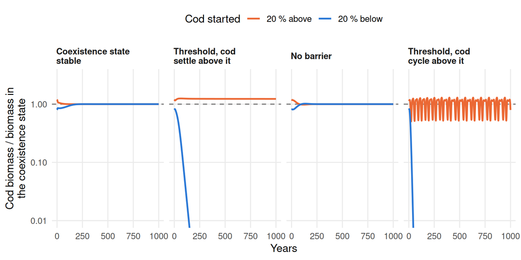

Figure 4: Cod biomass after cod are started 20 % below and 20 % above the coexistence state, at the four points of Table 2.

```r
dep <- cases$departures
dep$point <- factor(dep$point, levels = pts$label)
# Period of the cycle at the fourth point: the lag beyond 40 years at which
# the last 500 years of the run from above correlate best with themselves
cycling <- dep$cod[dep$point == pts$label[4] & dep$factor > 1 &
                       dep$time > max(dep$time) - 500]
cycle_period <- which.max(acf(cycling, lag.max = 200,
                              plot = FALSE)$acf[-(1:41)]) + 40
dep$start <- factor(ifelse(dep$factor < 1, "20 % below", "20 % above"),
                    levels = c("20 % above", "20 % below"))
ggplot(dep, aes(time, cod, colour = start)) +
    geom_hline(yintercept = 1, colour = "grey45", linetype = "dashed") +
    geom_line(linewidth = 0.9) +
    facet_wrap(~point, ncol = 4, labeller = label_wrap_gen(20)) +
    scale_y_log10() +
    coord_cartesian(ylim = c(0.01, 3)) +
    scale_colour_manual(values = c("#eb6834", "#2a78d6"),
                        name = "Cod started") +
    labs(x = "Years", y = "Cod biomass / biomass in\nthe coexistence state")
```

Figure 4 shows the runs from below and above at the four points of Table 2:

- **Where the coexistence state is stable**, with or without a barrier, cod return to it within about 300 years.
- **Where it is the threshold**, cod started below it die out. Cod started above it settle at 1.23 times their coexistence biomass at the second point. At the fourth they cycle between 0.52 and 1.3 times that biomass, in a pattern that repeats about every 78 years.

## 4.3 Decomposition

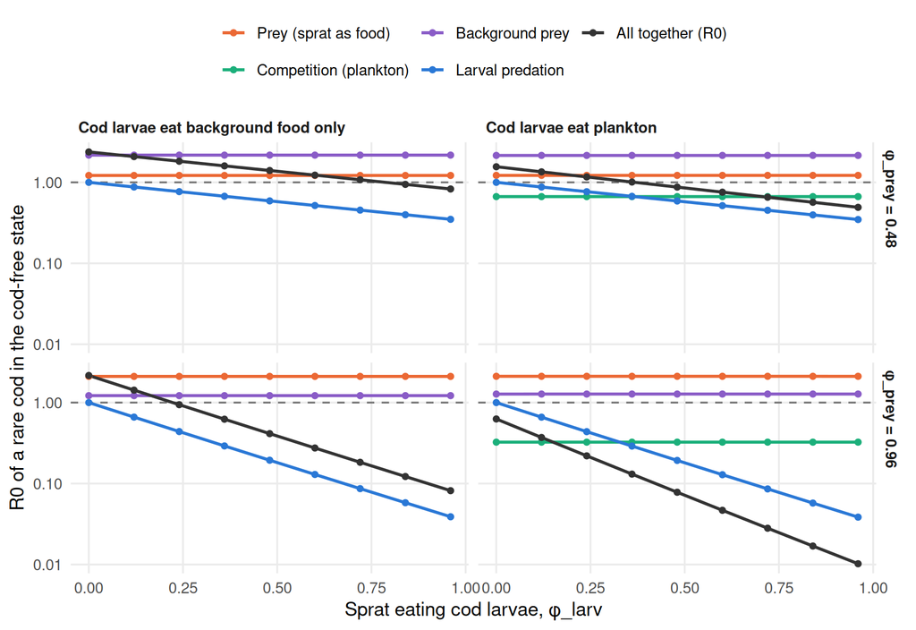

Figure 5: The factors of $R_0$ along the strength of sprat predation on cod larvae, at two strengths of cod predation on sprat (rows). The prey factor and the background factor are above 1 throughout: sprat as food and the background prey work against the Allee effect.

```r
dec <- scan[scan$phi_prey %in% c(0.48, 0.96), ]
factors <- c(prey = "Prey (sprat as food)",
             competition = "Competition (plankton)",
             background = "Background prey",
             larval_predation = "Larval predation",
             R0 = "All together (R0)")
dec_long <- do.call(rbind, lapply(names(factors), function(f) {
    data.frame(dec[c("phi_prey", "phi_larv", "variant")],
               factor = factors[[f]], value = dec[[f]])
}))
dec_long$factor <- factor(dec_long$factor, levels = factors)
dec_long$row <- paste("φ_prey =", dec_long$phi_prey)
# Without cod feeding on plankton there is no competition
dec_long <- dec_long[!(dec_long$factor == factors[["competition"]] &
                           dec_long$variant == levels(scan$variant)[1]), ]
ggplot(dec_long, aes(phi_larv, value, colour = factor)) +
    geom_hline(yintercept = 1, colour = "grey45", linetype = "dashed") +
    geom_line(linewidth = 0.9) +
    geom_point(size = 1.4) +
    facet_grid(row ~ variant) +
    scale_y_log10() +
    scale_colour_manual(values = c("#eb6834", "#1baf7a", "#8a5cc7", "#2a78d6",
                                   "grey20"), name = NULL) +
    labs(x = "Sprat eating cod larvae, φ_larv",
         y = "R0 of a rare cod in the cod-free state") +
    guides(colour = guide_legend(nrow = 2))
```

The factors in Figure 5 behave very differently:

- **Prey** is 1.01–2.11: above 1 wherever cod eat sprat. It depends on `phi_prey` only. A rare cod in the cod-free state finds more adult sprat and grows faster through the sizes of 30 g to 1 kg. As in the cultivation–depensation study, food works *against* depensation.
- **Competition** is 0.32–0.92 when cod larvae eat plankton. It too depends on `phi_prey` only, through the number of sprat in the cod-free state.
- **Background** is 1.22–3.06: above 1 everywhere, and largest where cod do not eat sprat at all. A rare cod has to itself the background prey that the cod of the coexistence state had eaten down. The factor falls as `phi_prey` rises, for two reasons:
  - cod then take more of their food from sprat and less from background prey;
  - there are more sprat without cod, and they graze the small background prey down, to as little as 0.55 of its abundance in the coexistence state.
- **Food**, all three together, is 2.16–3.06 without competition and 0.63–3.06 with it. Food alone closes the cod-free state only when cod larvae eat plankton and `phi_prey` is 0.84 or more. At strong links it is less than the product of its three parts, because a cod that is already well fed gains little from more food.
- **Larval predation** is 0.04–0.97. It needs both links: `phi_larv` for sprat to eat cod larvae, and `phi_prey` for there to be more sprat without cod.
- **Interaction** is 0.42–1.00 with competition and 0.97–1.00 without. Cod larvae short of plankton grow slowly through the sizes at which sprat eat them, so competition and larval predation amplify each other. Sprat as prey and the background prey hardly interact with larval predation, because cod eat them mostly once they have outgrown it.

## 4.4 Introductions

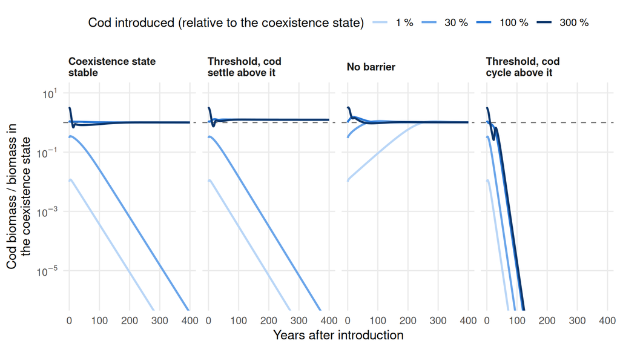

Figure 6: Cod biomass after cod are introduced into the cod-free state at a multiple of their abundance in the coexistence state.

```r
intro$point <- factor(intro$point, levels = pts$label)
intro_factors <- sort(unique(intro$factor))
intro$introduced <- factor(paste0(100 * intro$factor, " %"),
                           levels = paste0(100 * intro_factors, " %"))
ggplot(intro, aes(time, cod, colour = introduced)) +
    geom_hline(yintercept = 1, colour = "grey45", linetype = "dashed") +
    geom_line(linewidth = 0.9) +
    facet_wrap(~point, ncol = 4, labeller = label_wrap_gen(20)) +
    scale_y_log10(labels = scales::label_log()) +
    coord_cartesian(ylim = c(1e-6, 10)) +
    scale_colour_manual(values = c("#b9d6f7", "#6aa5ea", "#2a78d6",
                                   "#0d366b"),
                        name = "Cod introduced (relative to the coexistence state)") +
    labs(x = "Years after introduction",
         y = "Cod biomass / biomass in\nthe coexistence state")
```

```r
intro_end <- intro[intro$time == max(intro$time), ]
outcome <- biomass_text(intro_end$cod)
outcomes <- sapply(intro_factors, function(f) {
    outcome[intro_end$factor == f][match(pts$label,
                                         intro_end$point[intro_end$factor == f])]
})
colnames(outcomes) <- paste0(100 * intro_factors, " %")
knitr::kable(data.frame(Point = pts$label, outcomes, check.names = FALSE),
             row.names = FALSE)
```

Table 3: Outcome of the introductions in Figure 6 after 400 years: cod biomass relative to the coexistence state.

| Point | 1 % | 30 % | 100 % | 300 % |
| --- | --- | --- | --- | --- |
| Coexistence state stable | dies out | dies out | 1.00× | 1.00× |
| Threshold, cod settle above it | dies out | dies out | 1.24× | 1.24× |
| No barrier | 1.02× | 1.01× | 1.01× | 1.01× |
| Threshold, cod cycle above it | dies out | dies out | dies out | dies out |

The introductions agree with the regime map (Figure 6, Table 3):

- **Where there is no barrier** (third point), cod establish from 1 % of their coexistence abundance and settle at the coexistence state.
- **Where the coexistence state is stable behind a barrier** (first point), 1 % and 30 % die out. An introduction at or above the coexistence abundance settles at the coexistence state.
- **Where it is the threshold and cod settle above it** (second point), 1 % and 30 % die out too. Larger introductions pass the threshold and settle above it, with sprat at 0.76 of their coexistence biomass.
- **At the fourth point** even three times the coexistence abundance dies out.

Note that these introductions go into the cod-free state, where sprat are more abundant than in the coexistence state. The coexistence abundance of cod is therefore not itself the threshold.

## 4.5 Fishing

Cod fishing uses the length-selective trawl of the earlier models, so $F_\text{cod}$ is the fishing mortality on fully selected cod. Three cod states are followed, at the first three points of Table 2:

- the coexistence state where it is stable behind a barrier;
- where it is the threshold, the state that cod reach from above it. That state has 1.23 times the cod and 0.78 times the sprat of the coexistence state, and no longer has power-law rates;
- the coexistence state where there is no barrier.

Each step projects the model until every biomass changes by less than $10^{-5}$/yr, starting from the state of the previous step. The downward sweep starts from the cod-free state, with cod topped up to $10^{-6}$ of their coexistence abundance before each step.

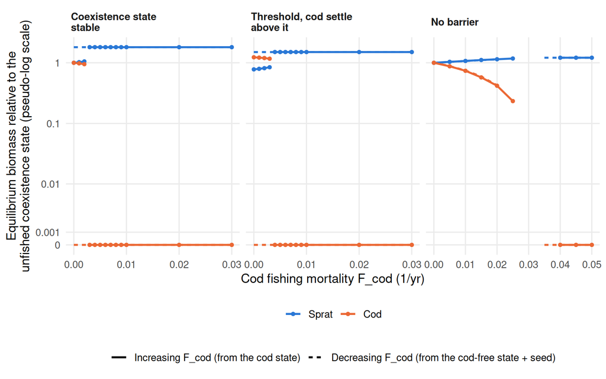

Figure 7: Equilibrium biomass under increasing (solid, with a point at each step, from the cod state) and decreasing (dashed, from the cod-free state with a cod seed) cod fishing, for the three cod states. Biomasses are relative to the unfished coexistence state. Note the different scales of the fishing mortality. Without a barrier the two sweeps coincide.

```r
# Draw only the branches of steady states, not the jumps between them: each
# sweep is split where cod move between the abundant state and the depleted
# one
settled <- fb[fb$converged, ]
settled$segment <- ave(as.numeric(settled$Cod > abundant),
                       paste(settled$case, settled$sweep),
                       FUN = function(a) cumsum(c(0, diff(a) != 0)))
long <- rbind(transform(settled, species = "Sprat", biomass = Sprat),
              transform(settled, species = "Cod", biomass = Cod))
long$species <- factor(long$species, levels = c("Sprat", "Cod"))
ggplot(long, aes(F_cod, biomass, colour = species)) +
    geom_line(aes(linetype = sweep,
                  group = interaction(species, sweep, segment)),
              linewidth = 0.9) +
    geom_point(data = long[long$sweep == fishing$sweeps[1], ], size = 1.2) +
    facet_wrap(~case, scales = "free_x", labeller = label_wrap_gen(24)) +
    scale_y_continuous(trans = scales::pseudo_log_trans(sigma = 1e-3),
                       breaks = c(0, 1e-3, 1e-2, 0.1, 1),
                       labels = c("0", "0.001", "0.01", "0.1", "1")) +
    scale_colour_manual(values = col_species) +
    labs(x = "Cod fishing mortality F_cod (1/yr)",
         y = "Equilibrium biomass relative to the\nunfished coexistence state (pseudo-log scale)",
         colour = NULL, linetype = NULL) +
    guides(colour = guide_legend(order = 1),
           linetype = guide_legend(order = 2)) +
    theme(legend.position = "bottom", legend.box = "vertical")
```

All three cod states withstand very little fishing (Figure 7). The cod state of the combined model persisted up to a fishing mortality of 0.27/yr.

- **The stable coexistence state behind a barrier** persists at $F_\text{cod}$ = 0.002/yr, with cod at 0.95 of their unfished biomass, and collapses at 0.003/yr.
- **The cod state above the threshold** persists at $F_\text{cod}$ = 0.003/yr, with cod at 1.2 times their coexistence biomass, and collapses at 0.004/yr.
- **Cod do not return** in these two cases at any fishing mortality, because a rare cod cannot invade the cod-free state ($R_0$ = 0.63 and 0.61).
- **Without a barrier there is no collapse and no hysteresis.** Cod biomass falls steadily, to 0.74 of the unfished biomass at $F_\text{cod}$ = 0.01/yr and 0.23 at 0.025/yr. Cod are gone at 0.04/yr. In between, at 0.03 and 0.035/yr, the runs had not settled after 3000 years. When fishing is reduced again cod return along the same branch: where both sweeps have settled they differ by at most 0.02 of the unfished biomass.

**Why so little?** These fishing mortalities are small next to the natural mortality of cod, which is 0.35/yr at 1 kg and 0.22/yr at 5 kg. But cod have little to compensate with:

- Their only density dependence is their food. At a background level of 0.5 the background prey can at most double when cod become rare.
- That gives a rare cod an $R_0$ of at most 3.06 in the scan, and of 1.27 at the third point. Where there is no barrier, fishing that lowers the lifetime reproduction of a cod by that factor removes cod.
- Behind a barrier the cod state is lost earlier, in a fold: it meets the threshold while cod are still abundant.

```r
sprat_columns <- function(d) {
    d <- d[match(sf1$F_sprat, d$F_sprat), ]
    data.frame(R0 = sprintf("%.2f", d$R0),
               Cod = ifelse(d$cod < alive, "dies out", sprintf("%.2f", d$cod)))
}
sprat_table <- cbind(sf1$F_sprat, sprat_columns(sf1), sprat_columns(sf2),
                     sprat_columns(sf3))
names(sprat_table) <- c("Sprat fishing F (1/yr)",
                        "R0, first point", "Cod, first point",
                        "R0, second point", "Cod, second point",
                        "R0, third point", "Cod, third point")
knitr::kable(sprat_table, align = "rrrrrrr")
```

Table 4: A fishery on sprat above 1 g, without cod fishing, at the first three points of Table 2: the invasion fitness of cod in the cod-free state, and cod biomass in the cod state relative to the unfished coexistence state.

| Sprat fishing F (1/yr) | R0, first point | Cod, first point | R0, second point | Cod, second point | R0, third point | Cod, third point |
| --- | --- | --- | --- | --- | --- | --- |
| 0.00 | 0.63 | 1.00 | 0.61 | 1.23 | 1.27 | 1.00 |
| 0.10 | 0.99 | 0.96 | 1.05 | 1.20 | 2.08 | 1.41 |
| 0.25 | 1.46 | 0.83 | 1.82 | 1.07 | 3.64 | 1.43 |
| 0.50 | 1.96 | 0.59 | 3.15 | 0.86 | 6.92 | 1.32 |
| 1.00 | 1.66 | 0.16 | 5.27 | 0.49 | 14.95 | 1.15 |

Van Leeuwen et al. (2008) proposed thinning the sprat to let cod recover, and in the combined model a sprat fishery did open the way back. Here it does too (Table 4):

- **It opens the cod-free state.** Fewer sprat eat fewer cod larvae, leave them more plankton and graze less of the small background prey. $R_0$ exceeds 1 from $F$ = 0.25/yr at the first point and from 0.1/yr at the second.
- **It also takes the adult sprat that cod eat.** Where cod depend on sprat, that lowers cod in the cod state: to 0.16 of their unfished biomass at the first point and 0.49 at the second, at $F$ = 1/yr.
- **At the third point**, where cod depend least on sprat, cod gain. Their biomass is 1.43 times the unfished one at $F$ = 0.25/yr.

## 4.6 Sensitivity

```r
sens$unstable <- sens$lead_re > 1e-6
knitr::kable(data.frame(
    Variant = sens$variant,
    `Sprat without cod` = sprintf("%.2f×", sens$sprat_free),
    Prey = sprintf("%.2f", sens$prey),
    Competition = sprintf("%.2f", sens$competition),
    Background = sprintf("%.2f", sens$background),
    `Larval predation` = sprintf("%.2f", sens$larval_predation),
    R0 = sprintf("**%.2f**", sens$R0),
    `Growth rate of the instability (1/yr)` = ifelse(
        sens$unstable, sprintf("%.3f", sens$lead_re), "stable"),
    `Cod from above` = above_text(sens$above_cod_min, sens$above_cod_max),
    check.names = FALSE), align = "lrrrrrrrr")
#' A column of the sensitivity table for one variant
sens_at <- function(variant, column) sens[[column]][sens$variant == variant]
```

Table 5: The second point of Table 2 with one parameter changed at a time. The last column gives cod biomass, relative to the coexistence state, 1000 years after a start 20 % above it. A range is that of the last 100 years.

| Variant | Sprat without cod | Prey | Competition | Background | Larval predation | R0 | Growth rate of the instability (1/yr) | Cod from above |
| --- | --- | --- | --- | --- | --- | --- | --- | --- |
| Baseline | 1.50× | 1.55 | 0.50 | 1.70 | 0.62 | **0.60** | 0.031 | 1.23× |
| Background level 0.2 | 1.49× | 1.53 | 0.50 | 3.27 | 0.62 | **0.99** | 0.013 | 0.04× |
| Background level 0.8 | 1.52× | 1.56 | 0.49 | 1.17 | 0.62 | **0.48** | 0.043 | 1.45× |
| Fixed background | 1.54× | 1.58 | 0.49 | 1.00 | 0.62 | **0.44** | 0.050 | 1.63× |
| Background prey 10 times as abundant | 1.50× | 1.55 | 0.50 | 1.70 | 0.62 | **0.60** | 0.046 | dies out |
| Plankton level 0.2 | 1.32× | 1.35 | 0.47 | 1.79 | 0.70 | **0.63** | 0.041 | 1.61× |
| Plankton level 0.8 | 2.20× | 2.21 | 0.53 | 1.44 | 0.38 | **0.42** | 0.020 | 1.02× |
| Feeding level 0.4 | 1.56× | 2.40 | 0.30 | 2.81 | 0.63 | **0.63** | stable | 1.00× |
| Feeding level 0.8 | 1.62× | 1.26 | 0.58 | 1.20 | 0.46 | **0.32** | 0.094 | 0.88× |
| Plankton up to 1 g | 1.51× | 1.55 | 0.40 | 1.85 | 0.62 | **0.58** | 0.036 | 1.29× |
| 320 size classes | 1.50× | 1.54 | 0.50 | 1.72 | 0.62 | **0.61** | 0.030 | 1.23× |

Table 5 varies what sets how strongly the species and the background respond, at the second point of Table 2:

- **The barrier persists in every variant**, with $R_0$ between 0.32 and 0.99. The prey factor stays above 1.
- **The background level decides how much of the barrier is left.**
  - The further the background prey gives way, the more a rare cod gains from having it to itself. The background factor is 3.27 at a level of 0.2 and 1.17 at 0.8.
  - $R_0$ is then 0.99 and 0.48. With a fixed background it is 0.44.
  - A background prey that gives way more also damps the instability: its growth rate is 0.013/yr at a level of 0.2 and 0.05/yr with a fixed background.
- **The abundance of the background prey** changes neither $R_0$ nor its factors. Prey that is ten times as abundant responds ten times as slowly. The instability then grows at 0.046/yr instead of 0.031/yr, and cod started above the threshold die out.
- **Plankton that gives way less** (plankton level 0.8) lets sprat increase more without cod. Larval predation then matters more and competition slightly less.
- **Sprat and cod closer to starvation** (feeding level 0.4) strengthen competition, but strengthen the prey factor and the background factor against it too. The coexistence state is then stable. Sprat still do not become stunted.
- **What happens above the threshold is not robust.** Cod started 20 % above it
  - settle above it in most variants;
  - settle below it, with sprat at 0.1 of their coexistence biomass (feeding level 0.8);
  - fall to 4 % of their coexistence biomass and go on falling slowly (background level 0.2);
  - or die out (abundant background prey).
- **The numerics do not matter much**: 320 size classes instead of 200 change $R_0$ by 1 %.

## 4.7 Density dependence in cod reproduction

```r
bh <- cases$reproduction
bh$stable <- bh$lead_re < 1e-6
bh$barrier <- bh$R0 < 0.999
# The same points without the stock-recruitment relation
bh_scan <- do.call(rbind, lapply(seq_len(nrow(bh)), function(i) {
    at(bh$phi_prey[i], bh$phi_larv[i], bh$cod_resource[i])
}))
bh$was_stable <- !bh_scan$unstable
bh$was_barrier <- bh_scan$barrier
bh_first <- bh[bh$level == min(bh$level), ]
```

The background prey gives cod a density dependence through their food. The mizerEcopath workflow normally ends by giving each species one in its reproduction as well: a Beverton–Holt stock–recruitment relation with a chosen reproduction level $L$, the ratio of recruitment to its maximum. That was tried for cod at 8 points of the scan (`phi_prey` 0.48 and 0.96, `phi_larv` 0.24 and 0.72, with and without cod larvae eating plankton), each with $L$ = 0.5 and 0.8. Without it the coexistence state is stable at 4 of these points, and 5 have a barrier. It does not widen the bistability:

- **It does not stabilise the coexistence state.** At all 4 points where the state is unstable it stays unstable for both values of $L$. The instability only grows more slowly.
- **It weakens the barrier.** To keep the coexistence state a steady state, `erepro` rises by a factor $1/(1-L)$, and with it $R_0$ at low density. The cod-free state stays closed only where $R_0$ was below $1 - L$: in 5 of the 16 runs.
- **Never both.** In all 5 runs with a barrier the coexistence state is unstable, and in all 8 runs where it is stable cod invade the cod-free state. The point that is bistable without the relation (`phi_prey` = 0.96, `phi_larv` = 0.24, cod larvae eating background food only) loses its barrier.

A stable coexistence state needs the density dependence at that state to outweigh the positive feedback there. A closed cod-free state needs the positive feedback, summed from no cod up to the coexistence abundance, to outweigh $1/(1-L)$. Both hold only if the positive feedback is much stronger at low cod abundance than at the coexistence abundance. Here it is not.

# 5 Comparison with the combined model

|  | Combined model | This model |
| --- | --- | --- |
| Community | Cod, sprat, plankton | The same, in a power-law background of fixed mortality and depletable prey |
| Cod state | Held fixed by recalibrating `erepro` | The same steady state for all link strengths, by construction |
| Sprat as food for cod | Barrier (the mechanism of Van Leeuwen et al.) for early diet shifts | Never a barrier: raises $R_0$ |
| Sprat eating cod larvae | Barrier | Barrier, down to a factor 0.038 |
| Competition for plankton | Excluded | Optional. A barrier when included |
| Other food of cod | None | Background prey that cod eat down. Works against the barriers |
| The two barriers together | Amplify each other | Larval predation and competition amplify each other. Sprat as food does not interact |
| Cod state | Stable up to moderate larval predation | Stable wherever cod can invade. Behind a barrier mostly the threshold, with a cod state above it |
| Cod fishing | The cod state persists up to 0.27/yr | The cod states behind a barrier collapse at 0.003/yr and 0.004/yr |
| Sprat fishery | Opens the way back | Opens the way back |
| Numerics | Second order, size diffusion | First-order upwind |

# 6 Caveats

- **The background responds only in part.**
  - Its mortality is fixed: the other predators of cod and sprat do not change in number or switch prey.
  - Background prey below 0.1 g is fixed. With cod larvae eating background food only, their food is therefore fixed.
  - The background prey has no dynamics of its own beyond the semichemostat: its size classes do not grow into each other or feed on the plankton.
- **Two numbers for the background prey are free choices.**
  - The background level sets how far the prey gives way. At 1 the background is fixed.
  - The abundance of the prey sets how fast it gives way, but not how far. It changes the eigenvalues and the transients, and leaves the steady states and $R_0$ as they are. Table 5 varies both.
- **Cod can compensate for little.** Their food is their only density dependence, and it gives a rare cod an $R_0$ of at most 3.06. That is why so little fishing removes them (Figure 7). The fishing mortalities here should not be read as estimates for a real stock.
- **One number scales each link.** The size pattern of each link (Figure 1) follows from the kernels and the spectra and is not a free choice. Small cod cannot be made to depend on small sprat without a kernel that changes with size.
- **One biomass ratio.** The biomasses of cod and sprat are those of the cod–sprat model. Their ratio decides how much sprat mortality cod can account for when cod depend fully on sprat.
- **Sprat respond weakly to food.** With a feeding level of 0.6, a critical level of 0.2 and plankton at half its capacity, sprat cannot become stunted. Table 5 varies these.
- **Stability.**
  - `getStability()` returns a ladder of real eigenvalues between about $-10^{-3}$/yr and rounding error, from sizes of plankton and background prey that no fish eats. They hide how strongly a stable state is damped, so only instability is read from the eigenvalues.
  - The fate of cod above the threshold comes from one projection, started with cod 20 % above the coexistence state and everything else unchanged, and judged after 1000 years. Such a start need not lie in the basin of a cod state above the threshold. Cycles were not characterised.
  - Large background prey responds slowly, because only the few large cod eat it: prey of 5 kg is replenished at 0.006/yr. Transients therefore take centuries.
- **Numerics.** First-order upwind on 200 size classes, with its numerical diffusion. With 320 classes $R_0$ at the second point of Table 2 changes by 1 %.
- **Internals.** `cod_R0()` calls mizer internals and was written against mizer 3.4.0.9001. The results here were computed with mizer 3.4.0.9003 and mizerEcopath 0.4.0.

# 7 Possible next steps

- A background mortality that responds: other predators that switch to cod or sprat when those are abundant.
- A background level chosen from data on how far cod deplete their other prey.
- More compensation in cod, so that the cod states withstand a realistic fishing mortality. A lower background level and density dependence in cod reproduction both give that, and both weaken the barriers.
- A diet of cod that shifts with size, so that small cod can depend on small sprat and the mechanism of Van Leeuwen et al. (2008) gets a fair chance in a power-law community.
- Sprat that are closer to starvation in the coexistence state (a lower feeding level for sprat only), so that they can become stunted.
- The fishing thresholds across the regime map, and a sprat fishery as a way back from the cod-free state.

# 8 Reproducing this document

| File | Contents |
| --- | --- |
| `R/background_model.R` | The model, the cod-free state, the stability measures and the decomposition of $R_0$ |
| `background/run_scan.R` | The scan over the two links; writes `background/scan.rds` |
| `background/run_cases.R` | Spectra, runs from below and above the coexistence state, introductions, sensitivity and density-dependent reproduction at single points; writes `background/cases.rds` |
| `background/run_fishing.R` | The branches under cod fishing and the effect of a sprat fishery; writes `background/fishing.rds` |
| `background_model.qmd` | This document; it reads the three results files |

```bash
OPENBLAS_NUM_THREADS=1 OMP_NUM_THREADS=1 Rscript background/run_scan.R
OPENBLAS_NUM_THREADS=1 OMP_NUM_THREADS=1 Rscript background/run_cases.R
OPENBLAS_NUM_THREADS=1 OMP_NUM_THREADS=1 Rscript background/run_fishing.R
quarto render background_model.qmd
```

The scan takes about an hour and a half on 4 cores, and the other two scripts about 35 and 20 minutes. The model needs the mizerEcopath package, which brings in mizerFromEcopath.

This document was rendered with mizer 3.4.0.9003, mizerEcopath 0.4.0 and R version 4.6.2 (2026-10-29).

# References

Van Leeuwen, Anieke, André M. De Roos, and Lennart Persson. 2008. “How Cod Shapes Its World.” *Journal of Sea Research* 60 (1-2): 89–104. https://doi.org/10.1016/j.seares.2008.02.008.

Walters, Carl, and James F. Kitchell. 2001. “Cultivation/Depensation Effects on Juvenile Survival and Recruitment: Implications for the Theory of Fishing.” *Canadian Journal of Fisheries and Aquatic Sciences* 58 (1): 39–50. https://doi.org/10.1139/f00-160.